# CS Final Project

Andrew Lin

2023-06-22

## Introduction

This is a project that analyzes worldwide terrorism rates. It uses the ‘Global Terrorism Database’ which contains cases of terrorism from 1970 - 2017 (excluding 1993). It has over 100 variables on information such as locations, outcomes, etc. The sources for the data in the data set are from unclassified media articles, so it is influenced by access to these media articles. The database is funded by START, the US Department of State and the US Department of Homeland Security Science and Technology Directorate’s Office of University Programs.

Code chunks can have code other than R. We can use css here to center our title.

```css
h1 {
  text-align: center;
}
```

The first thing we’ll do is import the libraries we’ll use to analyze the data in the dataset.

```r
knitr::opts_chunk$set(warning = FALSE, message = FALSE)
#the readr library offers a better and faster function for importing data files from the computer
library(readr)

#the dplyr library offers more intuitive functions for data wrangling than base r
#also provides the pipe function '%>%'
library(dplyr)

#ggplot is the go to library for plotting things in r
library(ggplot2)

#gganimate builds on ggplot, allowing us to animate our graphs
library(gganimate)

#leaflet is a library for building interactive maps
library(leaflet)

#a library that allows us to work with GIS data in r
library(rgdal)

#a library that allows us to do things with colours
library(RColorBrewer)
```

Then we’ll import the data into R from our computer.

```r
#Gets the data as a dataframe

#data <- data.table::fread("C:\\Users\\yongl\\Documents\\RStuff\\globalterrorismdb_0718dist.csv")
data <- read_csv("C:\\Users\\yongl\\Documents\\RStuff\\globalterrorismdb_0718dist.csv")
#data <- read_excel("C:\\Users\\yongl\\Documents\\RStuff\\globalterrorismdb_0718dist.xlsx")
```

## Basic Analysis

The data set is very large and has many variables, so for some basic analysis, let’s find the countries with the most occurrences of terrorism from 1970-2017. We can see Iraq has had the most cases of terrorism.

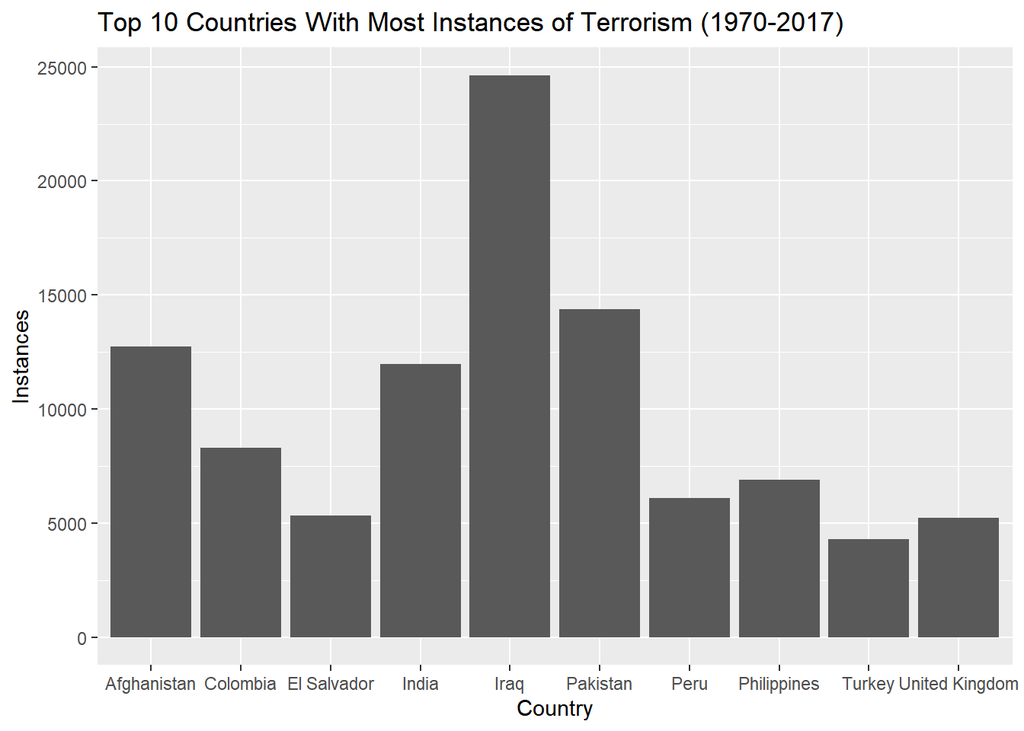

```r
#Counts the total occurrences of countries in the dataframe
Instances <- data %>% count(country_txt)

#Arranges the countries in descending order and gets the top 10
top10Instances <- Instances %>% arrange(desc( n))
top10Instances <- top10Instances[1:10,]

#Plots the data as a bar graph
ggplot(top10Instances, aes(x = country_txt, y = n)) + geom_col() + labs(x = 'Country', y = 'Instances', title = 'Top 10 Countries With Most Instances of Terrorism (1970-2017)')
```

The same can also be done to find the countries with the least amount of terrorism occurrences. Note: all countries have had at least 1 terrorism case, and it was more than a 5 way tie to show up in the graph.

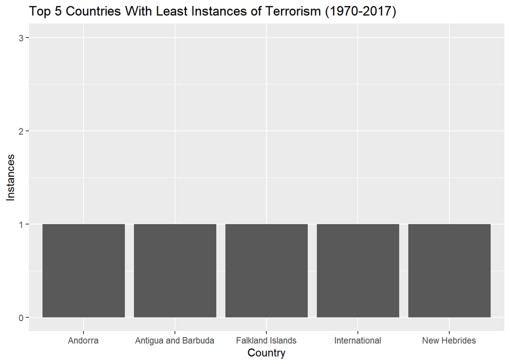

```r
#Finds the top 5 countries with the least instances
least5Instances <- Instances %>% arrange(n)
least5Instances <- least5Instances[1:5,]

#Plots the data as a bar graph
ggplot(least5Instances, aes(x = country_txt, y = n)) + geom_col() + labs(x = 'Country', title = 'Top 5 Countries With Least Instances of Terrorism (1970-2017)') + scale_y_continuous(name = 'Instances', limits = c(0,3))
```

## Animating Trends Over Time

We can also see the number of attacks per year. After around the year 2005, attacks significantly increased.

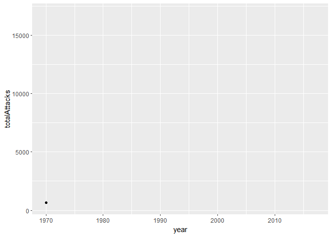

```r
#Makes a dataframe that has the year and terrorism instance count for that year
yearCount <- count(data, iyear)

#changes the column names
colnames(yearCount)[2] <- 'totalAttacks'
colnames(yearCount)[1] <- 'year'

#saves an animation
#Pipes a ggplot line graph into a function to animate it.
animation <- ggplot(yearCount, aes(x = year, y = totalAttacks)) + geom_line( color = "#FF6666") + geom_point() + transition_reveal(year)

#Animates the line graph of 100 frames at 7 frames per second
animate(animation, nframes = 100, fps = 7)
```

## Finding Success to Failure Ratio and Most Successful Groups

We can filter for only terrorist groups that have had successful attacks.

```r
#Filters for only the attacks that were successful
groupSuccessful <- data %>% filter(success == 1) %>% select(gname, success)

#Counts the successes of groups
numberOfSuccesses <- groupSuccessful %>% count(gname) %>% arrange(desc(n))

#changes column names
colnames(numberOfSuccesses)[2] <- "Successes"
colnames(numberOfSuccesses)[1] <- "Group Names"
```

We can also find the groups that have had the most attacks.

```r
#Counts the group that appears the most in dataset
numberOfAttacks <- data %>% count(gname) %>% arrange(desc(n))

#changes column names
colnames(numberOfAttacks)[2] <- 'Attacks'
colnames(numberOfAttacks)[1] <- 'Group Names'

#turns the dataframe into a paged table
numberOfAttacks %>% rmarkdown::paged_table()
```

| Group Names | Attacks |
| --- | --- |
| Unknown | 82782 |
| Taliban | 7478 |
| Islamic State of Iraq and the Levant (ISIL) | 5613 |
| Shining Path (SL) | 4555 |
| Farabundo Marti National Liberation Front (FMLN) | 3351 |
| Al-Shabaab | 3288 |
| New People's Army (NPA) | 2772 |
| Irish Republican Army (IRA) | 2671 |
| Revolutionary Armed Forces of Colombia (FARC) | 2487 |
| Boko Haram | 2418 |

[output cut: 3527 more lines]

Now we can find what terrorist groups have the best success to failure ratios.

```r
#lines up the 'numberOfAttacks' column and 'numberOfSuccesses' column by group names
successRate <- merge(numberOfAttacks, numberOfSuccesses, by.x = 'Group Names')

#creates a new column in dataframe that represents the success rates
successRate <- mutate(successRate, Ratio = successRate[[3]]/successRate[[2]])

#arranges in descending order of success ratio
successRate <- successRate %>% arrange(desc(Ratio),desc(Attacks))

#turns the dataframe into a paged table
successRate %>% rmarkdown::paged_table()
```

| Group Names | Attacks | Successes | Ratio |
| --- | --- | --- | --- |
| Nicaraguan Resistance | 231 | 231 | 1.0000000 |
| Democratic Revolutionary Alliance (ARDE) | 141 | 141 | 1.0000000 |
| Revolutionary Organization of People in Arms (ORPA) | 117 | 117 | 1.0000000 |
| Movement of Democratic Forces of Casamance | 79 | 79 | 1.0000000 |
| Naxalites | 67 | 67 | 1.0000000 |
| Sindhu Desh Liberation Army (SDLA) | 57 | 57 | 1.0000000 |
| Inkatha Freedom Party (IFP) | 50 | 50 | 1.0000000 |
| Left-Wing Terrorists | 50 | 50 | 1.0000000 |
| Niger Delta Avengers (NDA) | 50 | 50 | 1.0000000 |
| Strikers | 48 | 48 | 1.0000000 |

[output cut: 3324 more lines]

Let’s say we’re interested in seeing the success rates of terrorist groups that are active and large enough to have more than 50 attacks.

```r
#selects only the groups with more than 50 attempted attacks
bigSuccessRate <- successRate %>% filter(Attacks > 50)

#arranges in descending order
bigSuccessRate <- bigSuccessRate %>% arrange(desc(Ratio))

#turns the dataframe into a paged table
bigSuccessRate %>% rmarkdown::paged_table()
```

| Group Names | Attacks | Successes | Ratio |
| --- | --- | --- | --- |
| Nicaraguan Resistance | 231 | 231 | 1.0000000 |
| Democratic Revolutionary Alliance (ARDE) | 141 | 141 | 1.0000000 |
| Revolutionary Organization of People in Arms (ORPA) | 117 | 117 | 1.0000000 |
| Movement of Democratic Forces of Casamance | 79 | 79 | 1.0000000 |
| Naxalites | 67 | 67 | 1.0000000 |
| Sindhu Desh Liberation Army (SDLA) | 57 | 57 | 1.0000000 |
| Hutu extremists | 168 | 167 | 0.9940476 |
| Fulani extremists | 511 | 506 | 0.9902153 |
| Nicaraguan Democratic Force (FDN) | 895 | 886 | 0.9899441 |
| Shanti Bahini - Peace Force | 99 | 98 | 0.9898990 |

[output cut: 197 more lines]

We can slightly change the code to view the information in ascending order instead now.

```r
#arranges in ascending order
smallSuccessRate <- bigSuccessRate %>% arrange(Ratio)

#turns the dataframe into a paged table
smallSuccessRate %>% rmarkdown::paged_table()
```

| Group Names | Attacks | Successes | Ratio |
| --- | --- | --- | --- |
| Black September | 120 | 37 | 0.3083333 |
| Dissident Republicans | 95 | 49 | 0.5157895 |
| Palestinian Extremists | 441 | 287 | 0.6507937 |
| Communist Party of Nepal - Maoist (CPN-Maoist-Chand) | 91 | 62 | 0.6813187 |
| Conspiracy of Cells of Fire | 57 | 39 | 0.6842105 |
| Ricardo Franco Front (Dissident FARC) | 62 | 44 | 0.7096774 |
| Resistenza | 73 | 53 | 0.7260274 |
| Left-Wing Militants | 173 | 130 | 0.7514451 |
| Terra Lliure | 62 | 47 | 0.7580645 |
| Jemaah Islamiya (JI) | 76 | 58 | 0.7631579 |

[output cut: 197 more lines]

It appears the Maoists have carried out quite a few terrorist attacks, I wonder where they geographically happened. We can first make a data frame that only include attacks carried out by maoists.

```r
#makes a dataframe that only contains attacks carried out by maoists
maoists <- data %>% filter(gname == 'Maoists')
```

## Making an Interactive Map

Now we can plot all of them on an interactive map.

```r
#downloads the map template, we only need to download it once
#download.file("http://thematicmapping.org/downloads/TM_WORLD_BORDERS_SIMPL-0.3.zip" , destfile="world_shape_file.zip")
#system("unzip world_shape_file.zip")

#loading spatial data
world_spdf <- readOGR(
  #finds where the shapefile is located
  dsn = getwd(),
  #layer is the name of shapefile
  layer = "TM_WORLD_BORDERS_SIMPL-0.3",
  #don't want to print a message
  verbose = FALSE
)

#makes a new column in maoists dataframe that represents the number of people wounded
maoists <- maoists %>% mutate(ncasualties = (nkill + nwound))

#define colorpalette for markers and chart legend
#values for which colour will change
paletteBins <- c(1, 5, 10, 20, 30, 50, 100)

#palette is 'yellow to red'
#domain = NULL means
colorPalette <- colorBin(palette = "YlOrRd", domain = NULL,  bins = paletteBins, na.color = 'transparent')

#converts the columns to a numeric value for plotting
maoists$latitude <- as.numeric(maoists$latitude)
maoists$longitude <- as.numeric(maoists$longitude)

#leaflet function takes in the template and adds things onto it
leaflet(world_spdf) %>%
  addTiles() %>%
  setView(lat = 0, lng = 0, zoom = 2) %>%
  #adds circles onto template
  #takes in the dataframe vectors and creates circle on map for each row in dataframe
  addCircles(       lng = ~maoists$longitude,
                    lat = ~maoists$latitude ,
                    radius = ~(((maoists$ncasualties)+10)**2.5),
                    weight = 1,
                    opacity = 1,
                    color = ~colorPalette(maoists$ncasualties),
                    fillColor = ~colorPalette(maoists$ncasualties),

                    fillOpacity = 0.8,

                    label = ~lapply(maoists$summary, htmltools::HTML)) %>%
    #makes the legend
    addLegend(pal = colorPalette, values = maoists$ncasualties, opacity=0.9, title = "Attacks", position = "bottomleft")
```

[interactive chart not shown]